# A Data Science Practitioner's Guide to HDBSCAN

## Author: Chau Nguyen

### A note on this tutorial:

In this post, I will introduce 2 density-based clustering methods: **Hierarchical DBSCAN - HDBSCAN***, an extension of the original DBSCAN, and a **hybdrid combination of HDBSCAN and DBSCAN.**

Instead of generating sample data of very clearly defined clusters to demonstrate how different clustering techniques group points, I want to try a more hands-on approach to this tutorial. I made this decision because I've found the majority of online tutorials on unsupervised learning methods rather unintutive - the tend to rely heavily on "toy" examples with generated unlabeled data distributed in such obvious ways that a child with 5 crayons can color the clusters correctly.

I've always found this approach to unsupervised learning rather frustrating and counterintuitive: on one hand, we're told that the data is unlabeled and thus the algorithms can "see" what humans can't. Yet by using toy data that can be grouped into "perfect" distinct blobs in human eyes, these machine learning tutorials often feel more like "Look, I could write math equations that color these points like a human would!" This approach is probably beneficial for many reasons. However, as a data scientist practitioner who wants to "see" how different algorithms and tuning parameters cluster data, I think visual demonstrations using a real-life dataset that's not too abstract works well for me, and that's how I will approach this tutorial.

We will revisit the following map of 2,123 unique liquor licenses of Wasington DC throughout the tutorial. The GPS coordinates of each point and the underlying shapefiles to create the map where downloaded from [OpenDC](https://opendata.dc.gov/datasets/liquor-licenses/explore) [1]. A liquor license holder is an entity like restaurant, liquor store, grocery store, brewery or catering business that are allowed to sell alcoholic beverages.

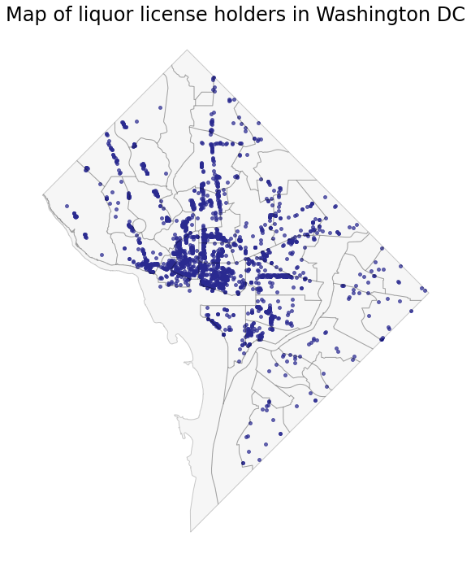

The above map divides the city into 46 neighborhood clusters, which is defined as "cluster boundaries were established in the early 2000s based on the professional judgment of the staff of the Office of Planning as reasonably descriptive units of the City for planning purposes" [[2]](https://opendata.dc.gov/datasets/DCGIS::neighborhood-clusters/about).

In a way, this is technically "cheating" as a map with GPS coordinates is not unlabelled data - we know the exact physical address of each restaurant or liquor store in the dataset. However, I thought this data would fit well to demonstrate an unsupervised learning technique because:

1) GPS coordinates are 2-dimensional and latitude & longitude are well defined and easily understood;

2) The distance between 2 points on a sphere can be measured precisely using the Harvesince formula;

3) We can visualize the output of clustering algorithms on a familiar map;

4) Using neighborhood clusters defined by the Office of Planning as a stand-in for human judgment/ domain expertise, we visualize and compare the outputs of these clustering algorithms.

# Brief introduction to Clustering:

Clustering refers to machine learning algorithms used to group sets of objects into sets of clusters. Objects grouped together into a cluster are similar or related to other objects in the same cluster, or dissimilar and unrelated to objects in other groups.

Clustering analysis can be thought of a classification technique - that is, it gives clustered data labels. However, because the labels is derived from the data itself, it is an **unsupervised learning** technique - as there is no outcome (labeled data) to compared the clusters to.

Popular clustering algorithms include:

1) K-means: Prototype-based clustering techniques create a one-level partitioning of the data objects.

2) Hierarchical Clustering: Two basic approaches for generating a hierarchical clustering:

- **Agglomerative:** Start with the points as individual clusters and, at each step, merge the closest pair of clusters.
- **Divisive:** Start with one, all-inclusive cluster and, at each step, split a cluster until only singleton clusters of individual points remain.

3) DBSCAN: Density-based clustering technique that determines clusters through locating regions of high density that are separated from one another by regions of low density.

For more in-depth understanding of the aforementioned clustering methods, I highly recommend chapter 7 of the book "Introduction to Data Mining" by Pang-Ning Tan, Michael Steinbach, Anuj Karpatne, and Vipin Kumar [1]. The following blog posts are also great resources: [The Most Comprehensive Guide to K-Means Clustering You’ll Ever Need](https://www.analyticsvidhya.com/blog/2019/08/comprehensive-guide-k-means-clustering/) [4], [What is Hierarchical Clustering?](https://www.kdnuggets.com/2019/09/hierarchical-clustering.html) [5], [DBSCAN Clustering Explained](https://towardsdatascience.com/dbscan-clustering-explained-97556a2ad556) [6].

# Detour: Quick recap of DBSCAN

In order to understand what HDBSCAN does, it is helpful to briefly discuss DBSCAN. (The reference blog post [6] explains the technique in great details). Please refer to the post if you don't know what DBSCAN does. If you are vaguely familar with DBSCAN, below are some points to help refresh your memories.

#### What it does:

- Finds objects with more than minimum number of neighbors ($minPts$) within a radius epsilon ($\epsilon$) - these objects are *core points*.
- Finds areas around that core point that satisfy minimum density based on $minPts$ and $\epsilon$ threholds.
- Does not perform density estimation in-between points - all neighbors within the $\epsilon$ radius of a core point are in the same cluster.

#### Main tuning parameters:

1) eps: epsilon or the radius of a point in relation to another point to be considered as points in the same neighborhood. NOT the maximum bound on distances of points within a cluster.

2) min_samples: number of samples in a neighborhood for a point to be considered as a core point. This includes the point itself.

#### Weaknesses:

1) eps is a global density threshold, isn’t useful for discovery of clusters with varying degrees of densities.

2) min_samplaes combined with epsilon are not intuitive parameters for areas with varying density levels.

Example: Person A has many neighbors within 100 meters of their apartment in NYC. Person B lives in upstate New York and only have 2 neighbors within the 1 mile radius. DBSCAN counts person A as a core point but not person B. This would not make practical sense for areas with different levels of densities.

### DBSCAN example

To understand how DBSCAN clusters points into group, let's revisit the map of DC liquor license holders we saw above.

Here, I choose the radius to be 0.5 km and set min_samples to be 5, which is the default in sklearn's implementation of DBSCAN [8]. The algorithm found 19 clusters in total, with the largest cluster (orange) spanning across multiple neighborhoods clusters.

Conversely, we also see points in South East neighborhoods that the algorithms cluster as noise (white points with black outline). This is because in those neighborhoods, liquor license holders are more spread out and DBSCAN fails to recognize them as "core point."

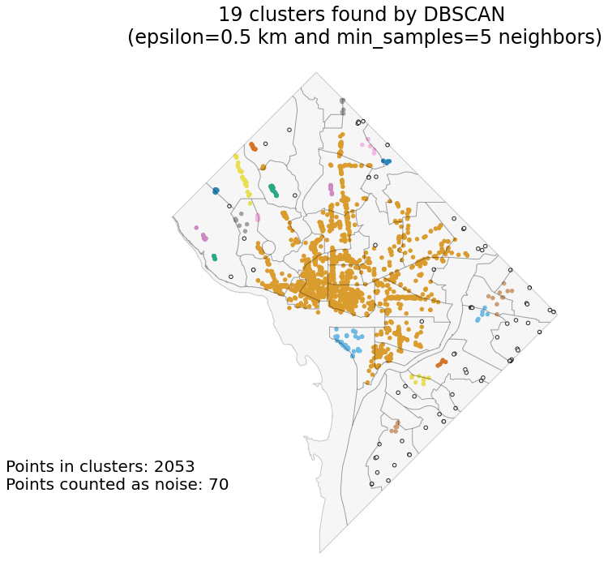

Lowering the radius parameter to 0.2km while keeping min_samples at 5, we can see that DBSCAN divides the liquor license holders into 55 clusters, successfully splitting up part of the large orange cluster. However, more points are considered "noise" with this new set of parameters - it still considers most of points in South East DC noise and there are new noise points in-between clusters in more dense areas.

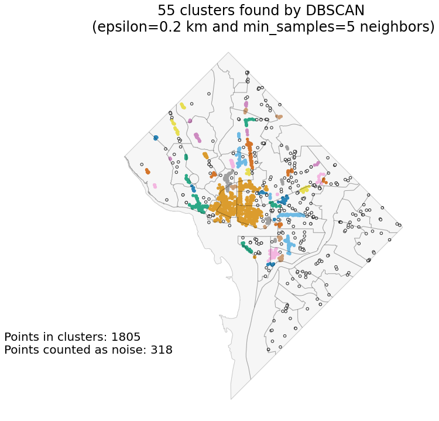

# Introducing Hierarchical DBSCAN

The 2 examples above show that DBSCAN does not work well when the data we're clustering have varying levels of sparsity, which brings us to a new technique: Hierarchical DBSCAN (or HDBSCAN). HDBSCAN was developed by Ricardo J. G. B. Campello, Davoud Moulavi, and Joerg Sander (one of the authors of the original DBSCAN technique) as an extension of the original DBSCAN. [7]

Because HDBSCAN is a relatively new method, it has yet been implemented in sklearn. We'll need to install it in our virtual environment using `pip install hdbscan`. Or if you prefer using conda, the prompt is `conda install -c conda-forge hdbscan`

## TL;DR Version

From a practical standpoint, HDBSCAN differs from DBSCAN that it:

- Allows varying degrees of densities for clusters -> does not use epsilon.
- Instead of using radius cut-off like DBSCAN, HDBSCAN **prunes trees** (more on this later).
- Starts off similar to DBSCAN: Requires a minimum number of points to form a cluster.

### Main tuning parameter:

- min_cluster_size: determine the smallest size a "blob" of points can be considered a cluster.

Before going into further technical details on the intuition behind HDBSCAN, I want to show how it splits our data. In this example, I set min_cluster_size = 5.

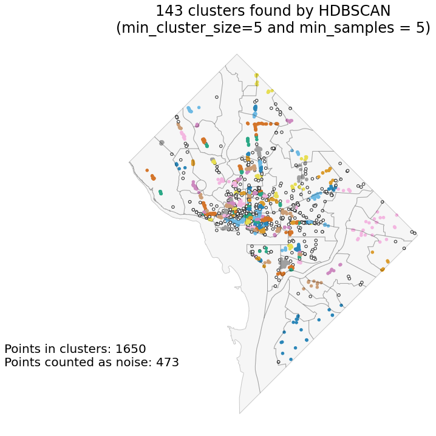

The difference is night-and-day! HDBSCAN splits our data into 143 clusters (let's hold off on discussing whether that's too many for now). Points in South East DC finally belong to some clusters, and the "Orange monster" earlier has been broken up even more. The algorithm recognizes that many points in the central area can form its own cluster, but also recognize a lot of those points as noise. This is because of the tree-pruning nature of HDBSCAN. The authors of the algorithms do a much better job at explaining the intuition behind this than I will ever have, so I will leave the link here: https://hdbscan.readthedocs.io/en/latest/how_hdbscan_works.html [10]. The purpose of this tutorial is to demonstrate how the parameters work in practice using visual examples that are easy to understand.

#### Note on min_samples

Ironically and counter-intuitively, min_samples exists as a parameter in HDBSCAN. "The simplest intuition for what min_samples does is provide a measure of how conservative you want your clustering to be. The larger the value of min_samples you provide, the more conservative the clustering – more points will be declared as noise, and clusters will be restricted to progressively more dense areas. The amount of data classified as noise is controlled by the min_samples parameter. By default, if not otherwise set, this value is set to the same value as min_cluster_size." [[9]](https://hdbscan.readthedocs.io/en/latest/parameter_selection.html#selecting-min-samples)

To demonstrate how min_samples affect the clustering of HDBSCAN, let's set it to 1. We can see that setting min_samples to 1 makes the algorithm more "liberal" with its definition of noise - counting fewer point as noise and creating more clusters than before.

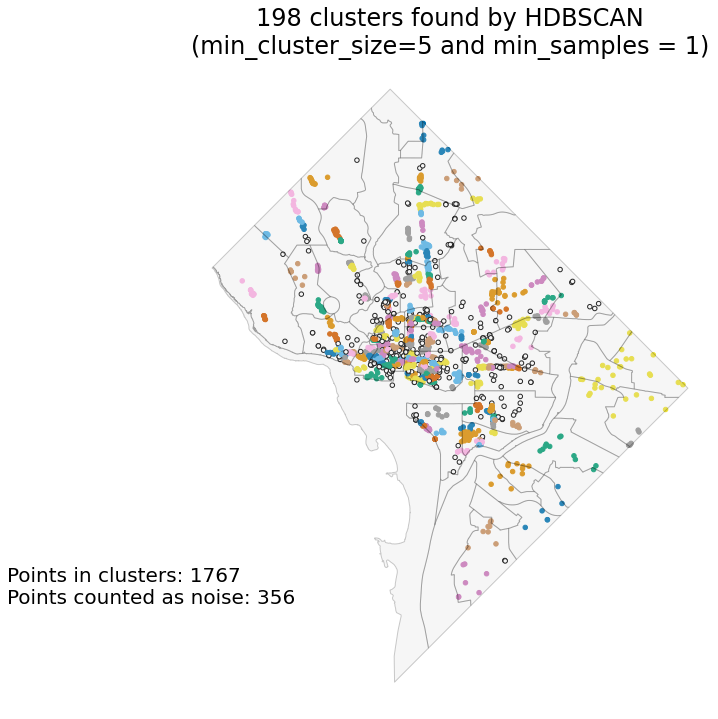

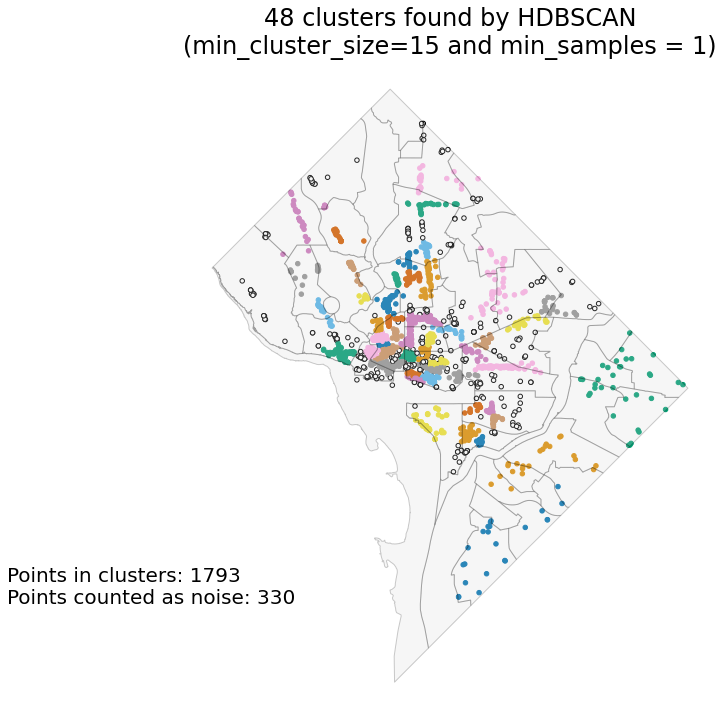

# Hybrid Approach: Combining DBSCAN and HDBSCAN

The `hdbscan` module includes additional parameters that allows us to combine HDBSCAN's tree pruning with DBSCAN's radius cutoff.

As HDBSCAN prunes its tree, for child nodes that are affected by the min_cluster_size parameter, instead of declaring those points "noise", the hybrid method merges blobs that HDBSCAN doesn't consider a full cluster based on min_cluster_size but are within a set radius (eps) of one another. [[11]](https://hdbscan.readthedocs.io/en/latest/how_to_use_epsilon.html)

For example, I can try reducing the min_cluster_size from 15 to 10. The "pure" HDBSCAN approach would return 79 clusters and discard 309 points as noise.

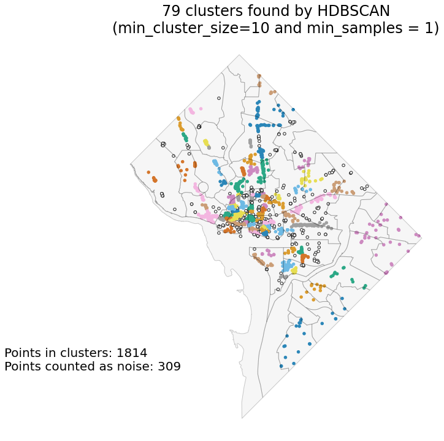

Combing epsilon = 5 km with HDBSCAN, we get fewer clusters, and fewer points are count as noise as well.

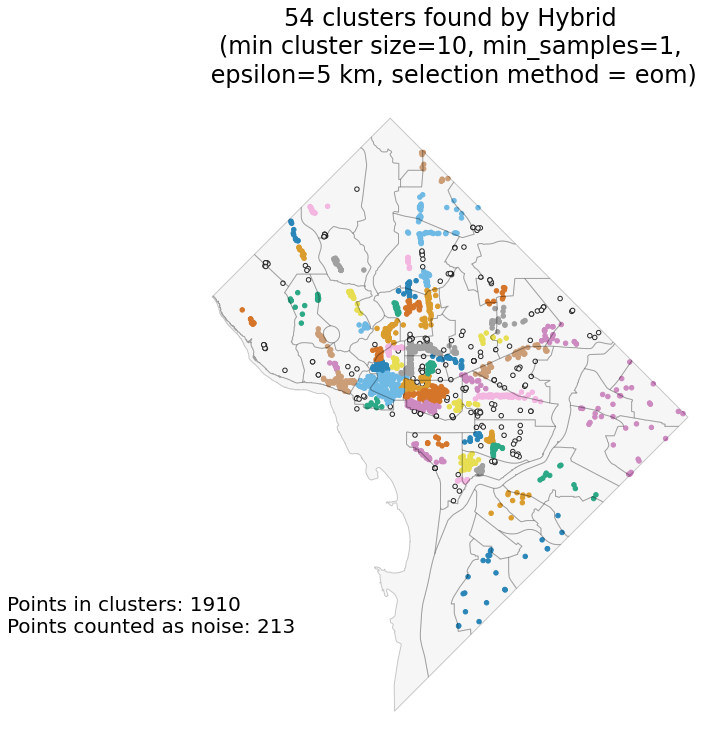

# Conclusion:

I hope this tutorial gave you an idea of different density-based techniques work in practice. The goal of this tutorial wasn't to necessarily explain the math behind each algorithms (I'm sure others a lot smarter than me can do this in much more succint ways), but to show you how each algorithms would cluster a real-life, unlabeled dataset that's somewhat familiar to us. I hope this tutorial gives you an appreciation for domain expertise and human judgment in data science overall, and especially with unsupervised machine learning. When data is labeled, it's easy to determine how well an algorithm works with scores and metrics. However, when data is unlabeled, how do we demonstrate our unsupervised algorithms in a way that doesn't alienate our audience? I hope I was able to achieve some of that through this tutorial.

#### Appendix: Cluster Selection parameter:

For HDBSCAN, the `cluster_selection_method` (default is `eom` but can be changed to leaf `leaf`) plays a role as well. In the words of the authors: "If you are more interested in having small homogeneous clusters then you may find Excess of Mass has a tendency to pick one or two large clusters and then a number of small extra clusters. In this situation you may be tempted to recluster just the data in the single large cluster. Instead, a better option is to select 'leaf' as a cluster selection method. This will select leaf nodes from the tree, producing many small homogeneous clusters. Note that you can still get variable density clusters via this method, and it is also still possible to get large clusters, but there will be a tendency to produce a more fine grained clustering than Excess of Mass can provide." [[12]](https://hdbscan.readthedocs.io/en/latest/parameter_selection.html)

However, in practice, I've found this parameter to not play that big a role, as demonstrated below.

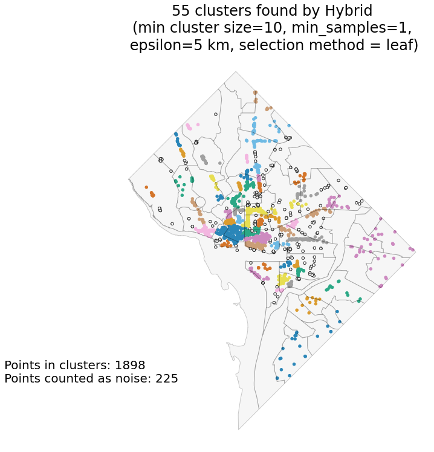

# References

[1]: "Liquor Licenses" - Open Data DC https://opendata.dc.gov/datasets/liquor-licenses/explore

[2] "Neighborhood Clusters" - Open Data DC https://opendata.dc.gov/datasets/DCGIS::neighborhood-clusters/about

[3]: "Introduction to Data Mining." (2005) Pang-Ning Tan, Michael Steinbach, Anuj Karpatne, and Vipin Kumar. ISBN: 0321321367 https://www.pearson.com/us/higher-education/program/Tan-Introduction-to-Data-Mining-2nd-Edition/PGM214749.html

[5]: "What is Hierarchical Clustering?" - Nagesh Singh Chauhan https://www.kdnuggets.com/2019/09/hierarchical-clustering.html

[6]: "DBSCAN Clustering Explained" - Soner Yıldırım https://towardsdatascience.com/dbscan-clustering-explained-97556a2ad556

[7]: "sklearn.cluster.DBSCAN" https://scikit-learn.org/stable/modules/generated/sklearn.cluster.DBSCAN.html

[8]: "Density-Based Clustering Based on Hierarchical Density Estimates" - Ricardo J. G. B. Campello, Davoud Moulavi, and Joerg Sander https://link.springer.com/chapter/10.1007/978-3-642-37456-2_14

[9] "Parameter Selection for HDBSCAN - Selecting `min_samples`" https://hdbscan.readthedocs.io/en/latest/parameter_selection.html#selecting-min-samples

[10] "How HDBSCAN works" - https://hdbscan.readthedocs.io/en/latest/how_hdbscan_works.html

[11] "How to use epsilon" - https://hdbscan.readthedocs.io/en/latest/how_to_use_epsilon.html

[12] "Parameter Selection for HDBSCAN - Leaf clustering" https://hdbscan.readthedocs.io/en/latest/parameter_selection.html